# Machine Learning Engineer Nanodegree

## Capstone Project

Rashid Kamran  
May 16, 2018

Proposal https://github.com/rkamran/MLE/blob/master/capstone/proposal.pdf  
Report https://github.com/rkamran/MLE/blob/master/smily_face/report.pdf

### Project imports

`config.py`, `dataprocessor.py` and `train.py` have mojority of the source code

```python
# Neccessary imports
import config
import dataprocessor
import train
from keras.models import load_model
from imutils.paths import list_images
```

# II. Analysis

Quickly checking the distribution of the data

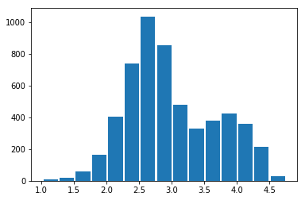

```python
import numpy as np
import matplotlib.pyplot as plt
%matplotlib inline

feature_file = config.FBP5500_SOURCE+"/train_test_files/All_labels.txt"
#Process feature dictionary
feature_dict = {}
with open(feature_file) as f:
    for line in f:
        (key, val) = line.split()
        feature_dict[key] = float(val)

all_scores = feature_dict.values()
hist, bins = np.histogram(list(all_scores), bins=15)

width = 0.9 * (bins[1] - bins[0])
center = (bins[:-1] + bins[1:]) / 2
plt.bar(center, hist, align='center', width=width)
plt.show()
```

## Preprocessing

Passing all dataset images through ResNet50 and storing extracted features into a .hdf5 databse.

```python
dataprocessor.process_FBP5500(config.FBP5500_SOURCE, config.DATABSE_FILE)
```

```
[INFO]Processing 124 remaining items
```

### Baseline

For establishing baseline I am using `sklearn.svm.SVR`. Since we have already extracted features so we can run it pretty quicly on a relative small dataset.

```python
from sklearn.svm import SVR
from sklearn.model_selection import train_test_split
import h5py
import numpy as np
from sklearn.metrics import regression

reg = SVR(kernel="rbf")
f = h5py.File(config.DATABSE_FILE, "r")

features = np.array(f["features"])
labels = np.array(f["labels"])

trainX, testX, trainY, testY = train_test_split(features, labels, test_size=0.1, shuffle=True)
reg.fit(trainX, trainY)

print("[INFO] Baseline Score (MSE) {}".format(regression.mean_squared_error(testY, reg.predict(testX))))
print("[INFO] Baseline Score (MAE) {}".format(regression.mean_absolute_error(testY, reg.predict(testX))))
```

```
[INFO] Baseline Score (MSE) 0.03521251652316297
[INFO] Baseline Score (MAE) 0.1318955946471878
```

### Dense Layer implementation

Adding a Dense layer on top of ResNet50 for regression

```python
import numpy as np
import matplotlib.pyplot as plt
%matplotlib inline

n_epochs = 20
# Train using MSE
H = train.train_FBP5500(config.DATABSE_FILE, config.MODEL_FILE, epochs=n_epochs)
```

```
Train on 4455 samples, validate on 495 samples
[INFO] Saving Model....
[INFO] Regression score (MSE) on test data 0.03983936458826065
```

# IV. Results

A look at the training history

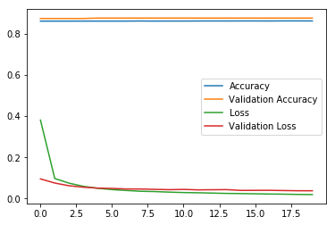

```python
# See how it went
x_axis = np.arange(0, n_epochs)
plt.figure()
plt.plot(x_axis, H.history["acc"], label="Accuracy")
plt.plot(x_axis, H.history["val_acc"], label="Validation Accuracy")
plt.plot(x_axis, H.history["loss"], label="Loss")
plt.plot(x_axis, H.history["val_loss"], label="Validation Loss")
plt.legend()
plt.show()
```

### Random Testing

Using totally diffrent images which I randomly collected to demonstrate the anecdotal performance of the mdoel

```python
from imutils.paths import list_images

image_files = list(list_images("./test_photos"))
print("[INFO] Total {} photos found".format(len(image_files)))

features =  dataprocessor.process_images(image_files)
print("Features extracted. Shape: {}".format(features.shape))

model = load_model(config.MODEL_FILE)
scores = model.predict(features)
```

```
[INFO] Total 24 photos found
Features extracted. Shape: (24, 350, 350, 3)
```

### Anecdotal proof and visual reassurance

Below is a grid of some personal, friends, random folks and celebrity photos. Model seems to be assigning high scores to celebrities and regressing back to mean when it comes to normal faces. In some cases I tried to stylize and was able to get some good score.

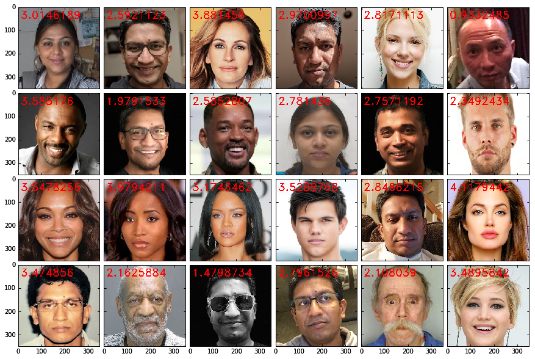

```python
import matplotlib.pyplot as plt
from mpl_toolkits.axes_grid import ImageGrid
%matplotlib inline
import numpy as np
import cv2
from math import ceil

scores = scores.reshape((1,-1))[0]

plt.style.use('seaborn-bright')
fig = plt.figure(1, (15., 15.))
grid = ImageGrid(fig, 111,  # similar to subplot(111)
                 nrows_ncols=(ceil(len(image_files)/6), 6),  # creates 2x2 grid of axes
                 axes_pad=0.1,  # pad between axes in inch.
                 )

font = cv2.FONT_HERSHEY_DUPLEX
for i, file in enumerate(image_files):
    im = cv2.cvtColor(cv2.imread(file), cv2.COLOR_BGR2RGB)
    cv2.putText(im, str(scores[i]), (10, 50), font, 1.5, (255,0,0), 2)
    grid[i].imshow(im)  # The AxesGrid object work as a list of axes.

plt.show()
```

### Converting into CoreML

This step will convert Kera's saved model into CoreML that I can use in iPhone app.

```python
import coremltools
from keras.models import load_model
model = load_model(config.MODEL_FILE)

coreML_model = coremltools.converters.keras.convert(model,
                                                    input_names="image",
                                                    image_input_names="image",
                                                    is_bgr=False)
coreML_model.save(config.COREML_MODEL_FILE)
```